# Data Visualization Lab - Key

# Part 1

Load the packages.

```r
library(tidyverse)
```

Load the CalEnviroScreen data from the link www.daseh.org/data/CalEnviroScreen_data.csv) and subset it so that you only have data from Fresno, Merced, Placer, Sonoma, and Yolo counties.

```r
ces <- read_csv("https://daseh.org/data/CalEnviroScreen_data.csv")
ces_sub <- ces |> filter(CaliforniaCounty %in% c("Fresno", "Merced", "Placer", "Sonoma", "Yolo"))
```

### 1.1

Use the `ggplot2` package to make a plot of how diesel particulate concentration (`DieselPM`; y-axis) is associated with traffic density values (`Traffic`; x-axis). You can use lines layer (`+ geom_line()`) or points layer (`+ geom_point()`), or both!

Assign the plot to variable `my_plot`. Type `my_plot` in the console to have it displayed.

`DieselPM`: Diesel PM emissions from on-road and non-road sources `Traffic`: Traffic density in vehicle-kilometers per hour per road length, within 150 meters of the census tract boundary

```
# General format
ggplot(???, aes(x = ???, y = ???)) +
  ??? +
  ???
```

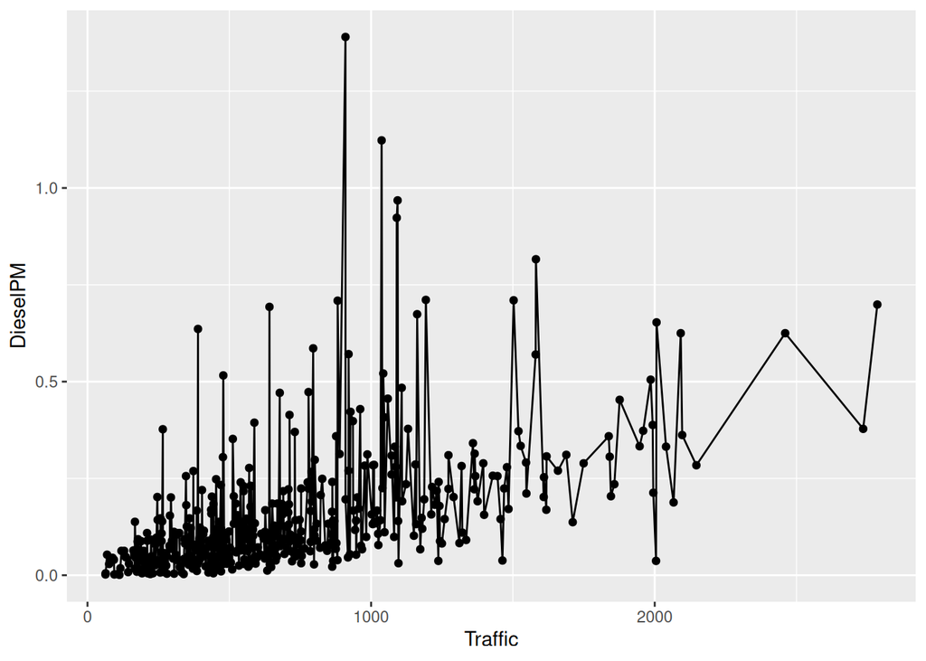

```r
my_plot <-
  ggplot(ces_sub, aes(x = Traffic, y = DieselPM)) +
  geom_line() +
  geom_point()

my_plot
```

### 1.2

“Update” your plot by adding a title and changing the x and y axis titles. (Hint: use the `labs` function.)

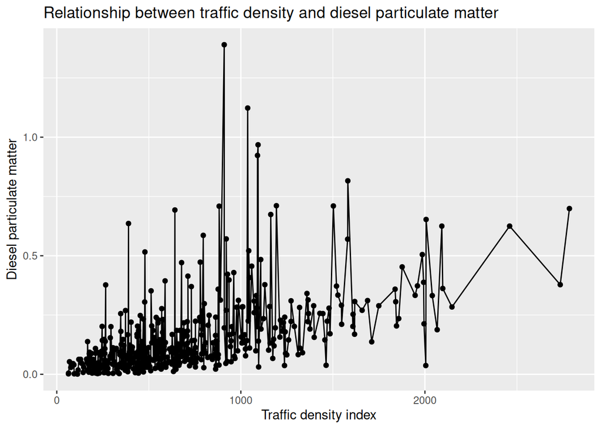

```r
my_plot <- my_plot +
  labs(
    x = "Traffic density index",
    y = "Diesel particulate matter",
    title = "Relationship between traffic density and diesel particulate matter"
  )

my_plot
```

### 1.3

Use the `scale_x_continuous()` function to plot the x axis with the following breaks `c(250, 750, 1250, 1750, 2250)`.

```
# General format
my_plot <- my_plot +
  scale_x_continuous(breaks = ???)
```

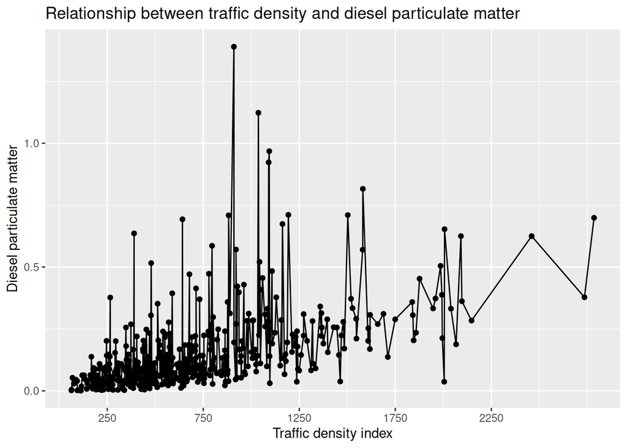

```r
my_plot <- my_plot +
  scale_x_continuous(
    breaks = c(250, 750, 1250, 1750, 2250)
  )

my_plot
```

### 1.4

Observe several different versions of the plot by displaying `my_plot` while adding a different “theme” to it.

```
# General format
my_plot + theme_bw()
```

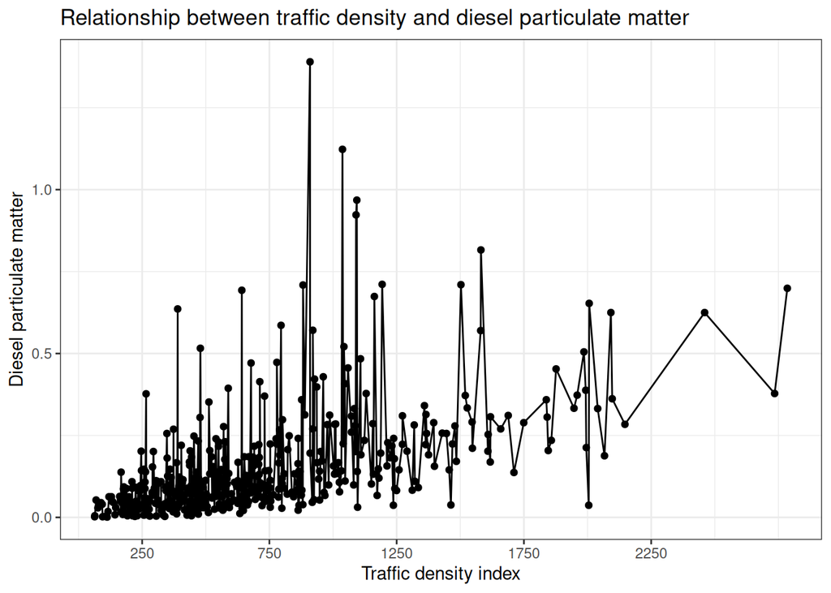

```r
my_plot + theme_bw()
```

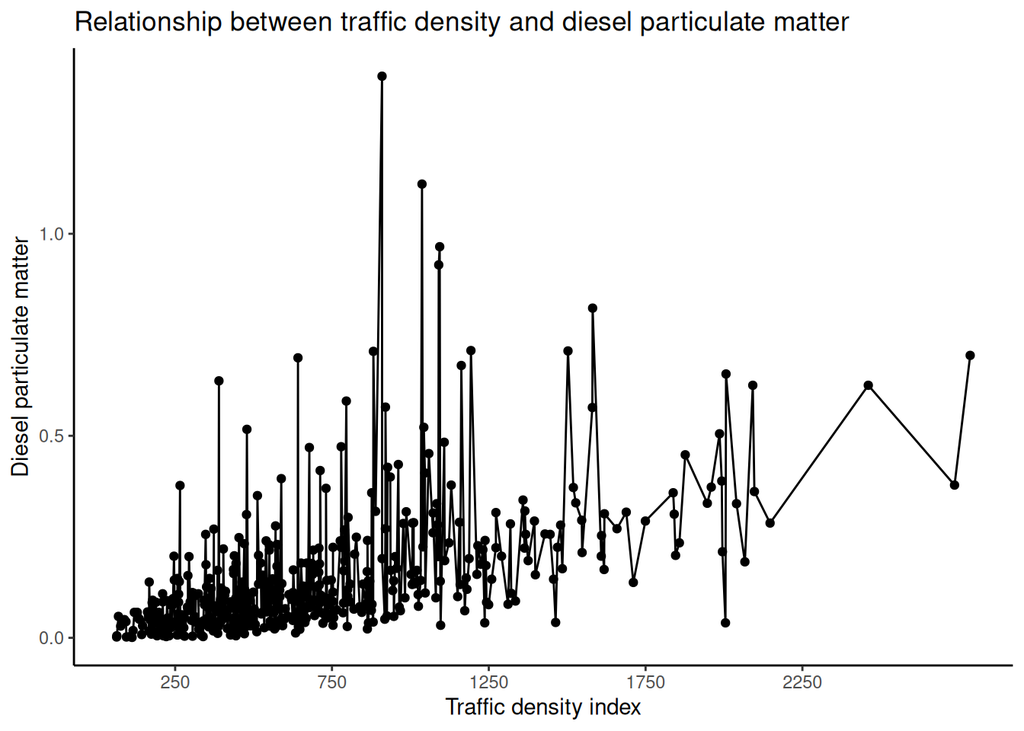

```r
my_plot + theme_classic()
```

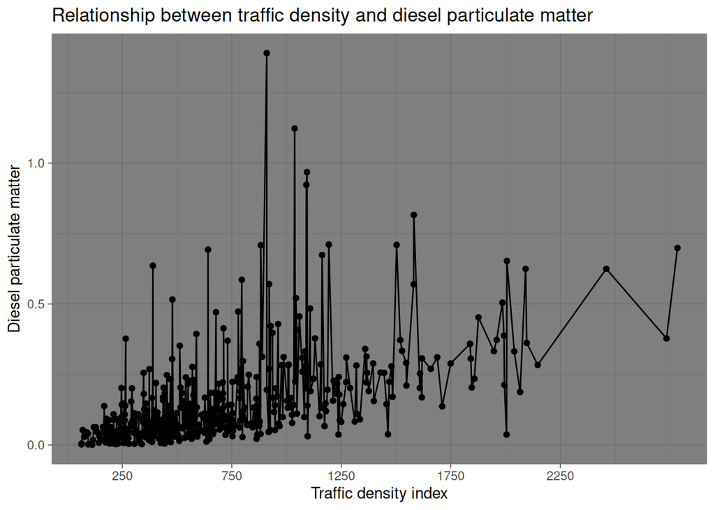

```r
my_plot + theme_dark()
```

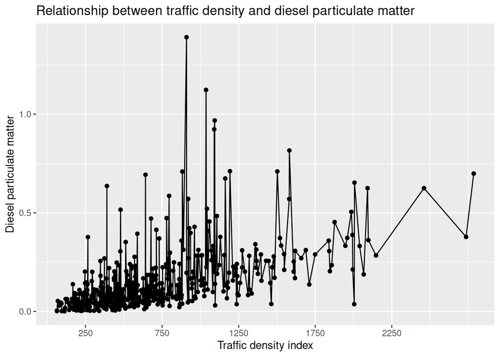

```r
my_plot + theme_gray()
```

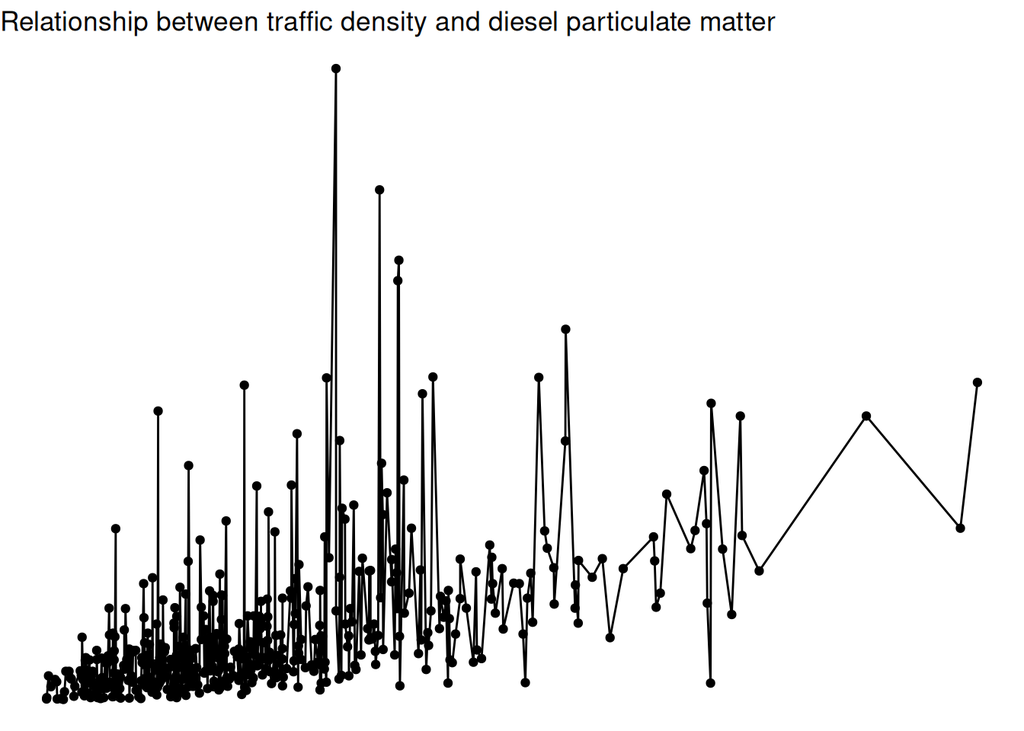

```r
my_plot + theme_void()
```

# Practice on Your Own!

### P.1

Create a boxplot (with the `geom_boxplot()` function) using the `ces_sub` data, where `CaliforniaCounty` is plotted on the x axis and `DrinkingWater` is plotted on the y axis.

`DrinkingWater`: Drinking water contaminant index for selected contaminants. A higher value means drinking water contains a greater volume of contaminants.

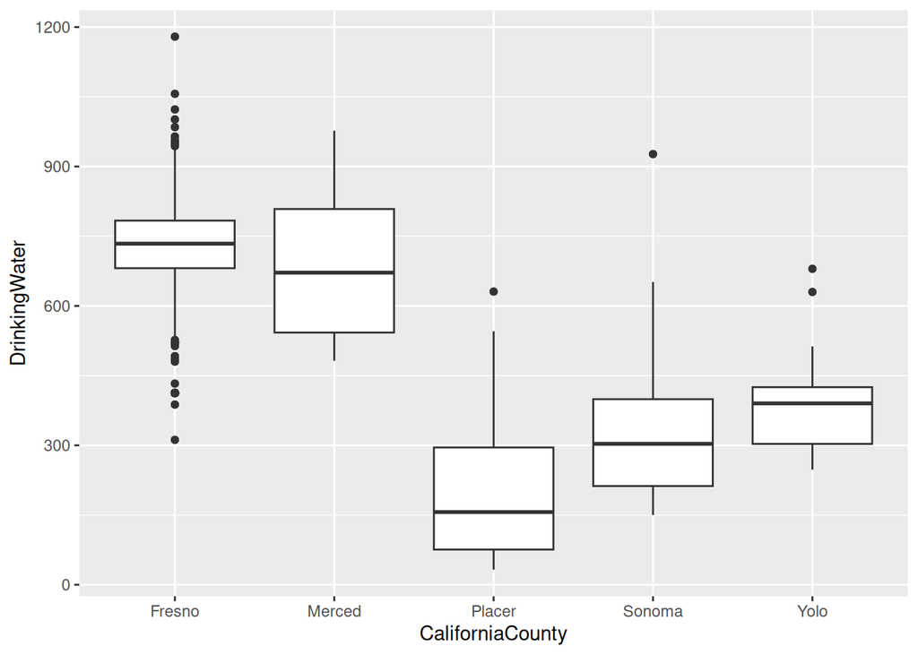

```r
ces_sub |>
  ggplot(aes(x = CaliforniaCounty, y = DrinkingWater)) +
  geom_boxplot()
```

# Part 2

### 2.1

Let’s look at the plot of traffic density and diesel particulate matter again,

Use `ggplot2` package make plot of how diesel particulate concentration (`DieselPM`; y-axis) is associated with traffic density values (`Traffic`; x-axis), where each county (`CaliforniaCounty`) has a different color (hint: use `color = CaliforniaCounty` in mapping).

```
# General format
ggplot(???, aes(
  x = ???,
  y = ???,
  color = ???
)) +
  geom_line() +
  geom_point()
```

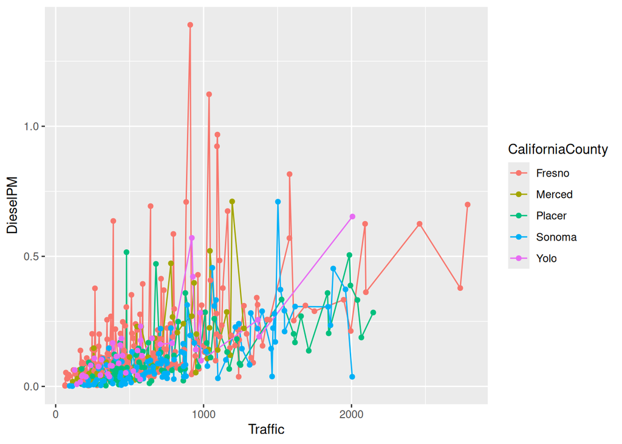

```r
ggplot(ces_sub, aes(
  x = Traffic,
  y = DieselPM,
  color = CaliforniaCounty
)) +
  geom_line() +
  geom_point()
```

### 2.2

Assign the new plot as an object called `facet_plot`.

Try adjusting the number of rows in the `facet_wrap` to see how this changes the plot.

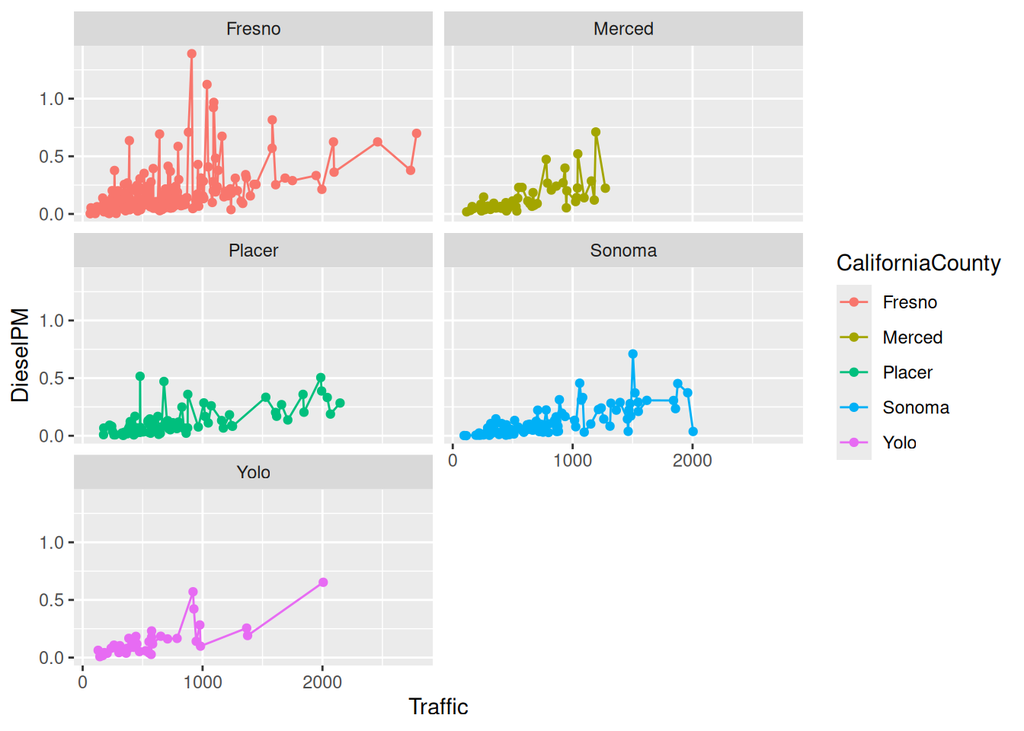

```r
facet_plot <- ggplot(ces_sub, aes(
  x = Traffic,
  y = DieselPM,
  color = CaliforniaCounty
)) +
  geom_line() +
  geom_point() +
  facet_wrap(~CaliforniaCounty, nrow = 3)

facet_plot
```

### 2.3

Observe what happens when you remove either `geom_line()` OR `geom_point()` from one of your plots above.

```r
# These elements are removed from the plot, like layers
```

# Practice on Your Own!

### P.2

Modify `facet_plot` to remove the legend (hint use `theme()` and the `legend.position` argument) and change the names of the axis titles to be “Diesel particulate matter” for the y axis and “Traffic density” for the x axis.

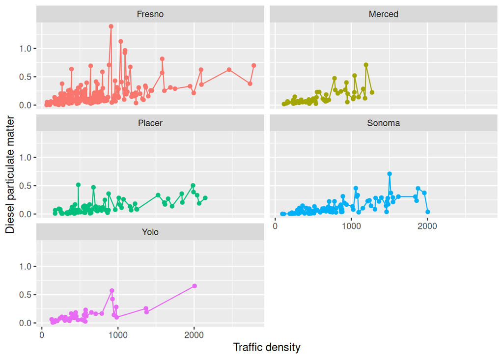

```r
facet_plot <- facet_plot +
  theme(legend.position = "none") +
  labs(
    y = "Diesel particulate matter",
    x = "Traffic density"
  )

facet_plot
```

### P.3

Modify `facet_plot` one more time with a fun theme! Look into the [ThemePark package](https://github.com/MatthewBJane/ThemePark). It has lots of fun themes! Try one out!

Remember you will need to install it and load it with `library(ThemePark)`.

```r
# Install ThemePark if necessary
install.packages("remotes")
remotes::install_github("MatthewBJane/ThemePark")
```

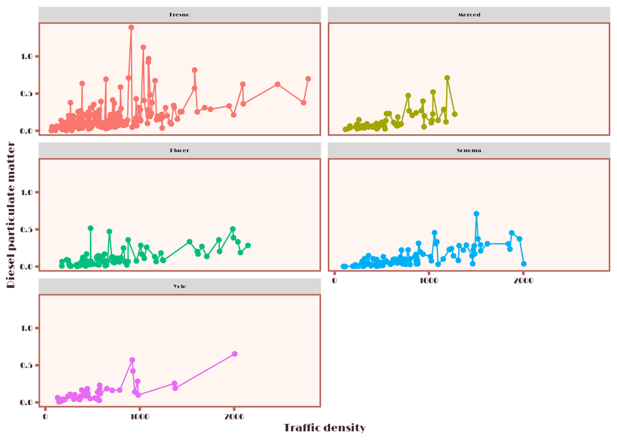

```r
library(ThemePark)

facet_plot + theme_grand_budapest()
```